# All-DAR Mutation Analysis

Zack Guo

UCL  
wegmzgu@ucl.ac.uk

September 16, 2026

# Library packages

```r
# Load packages for genomic overlaps, tables, and plotting.
library(GenomicRanges)
library(GenomeInfoDb)
library(rtracklayer)
library(dplyr)
library(tidyr)
library(ggplot2)
```

# Aim

This notebook compares mutation density across all mapped significant hepatocyte- and biliary-associated DARs. Unlike the previous analysis, it does not select genomic bins using the tumour mutation data.

# Input data

Notebook 04 screens the eight `Com01-04` H/I tumour-normal VCFs. The same screened SNVs are used here without changing the filtering criteria.

```r
project_dir <- "C:/Bioinfo data/cell of origin"
out_dir <- file.path(project_dir, "practice_results")

# Read the eight-sample screened SNV table produced by notebook 04.
input_path <- file.path(out_dir, "screened_somatic_snvs.tsv")
stopifnot(file.exists(input_path))
snvs <- read.delim(input_path)

labelled_samples <- as.vector(rbind(
  paste0("Com0", 1:4, "H"),
  paste0("Com0", 1:4, "I")
))
snvs <- filter(snvs, sample %in% labelled_samples)
stopifnot(setequal(unique(snvs$sample), labelled_samples))

# Convert the screened SNVs to one-base genomic ranges.
snv_gr <- makeGRangesFromDataFrame(
  snvs,
  seqnames.field = "chr",
  start.field = "pos",
  end.field = "pos",
  keep.extra.columns = TRUE
)

data.frame(
  sample = labelled_samples,
  screened_snvs = as.integer(table(snvs$sample)[labelled_samples]),
  source_file = basename(input_path)
)
```

| sample | screened_snvs | source_file |
| --- | --- | --- |
| Com01H | 1926 | screened_somatic_snvs.tsv |
| Com01I | 2328 | screened_somatic_snvs.tsv |
| Com02H | 2741 | screened_somatic_snvs.tsv |
| Com02I | 8410 | screened_somatic_snvs.tsv |
| Com03H | 1419 | screened_somatic_snvs.tsv |
| Com03I | 5301 | screened_somatic_snvs.tsv |
| Com04H | 15103 | screened_somatic_snvs.tsv |
| Com04I | 44394 | screened_somatic_snvs.tsv |

# Load all lineage-associated DARs

Correcting the bulk ATAC sample identities in notebook 03 reverses the biological interpretation of the two existing human-coordinate BED files but does not change their coordinates or which peaks are significant. Therefore, the previous biliary-named BED is used as the corrected hepatocyte reference, and the previous hepatocyte-named BED is used as the corrected biliary reference. No new liftOver is required.

```r
autosomes_x <- paste0("chr", c(1:22, "X"))

# Import one human-coordinate DAR BED file and merge overlapping intervals.
read_dar <- function(path) {
  dar <- import(path, format = "BED")
  keepSeqlevels(
    dar,
    intersect(seqlevels(dar), autosomes_x),
    pruning.mode = "coarse"
  ) %>% reduce()
}

# The old BED filenames reflect the previously reversed sample assignment.
hep_dar <- read_dar("C:/Bioinfo data/billiaryhuman.bed")
bil_dar <- read_dar("C:/Bioinfo data/hepatocytehuman.bed")

hep_mb <- sum(width(hep_dar)) / 1e6
bil_mb <- sum(width(bil_dar)) / 1e6
stopifnot(hep_mb > 0, bil_mb > 0)

dar_reference_summary <- data.frame(
  dar_set = c("hepatocyte", "biliary"),
  n_intervals = c(length(hep_dar), length(bil_dar)),
  Mb = c(hep_mb, bil_mb)
)

write.table(
  dar_reference_summary,
  file.path(out_dir, "all_dar_reference_sizes.tsv"),
  sep = "\t",
  row.names = FALSE,
  quote = FALSE
)

dar_reference_summary
```

| dar_set | n_intervals | Mb |
| --- | --- | --- |
| hepatocyte | 1010 | 0.563686 |
| biliary | 2696 | 1.825106 |

# Calculate all-DAR scores

The lineage score corrects for the different total sizes of the two DAR sets. The `0.5` pseudocount keeps the log-ratio finite when a DAR set contains no retained mutation.

```r
# Apply the same all-DAR score to each of the eight samples.
dar_summary <- lapply(labelled_samples, function(sample_id) {
  sample_gr <- snv_gr[mcols(snv_gr)$sample == sample_id]
  hep_count <- sum(countOverlaps(sample_gr, hep_dar) > 0)
  bil_count <- sum(countOverlaps(sample_gr, bil_dar) > 0)

  data.frame(
    sample = sample_id,
    patient = substr(sample_id, 1, 5),
    known_label = case_when(
      grepl("^Com0[1-4]H$", sample_id) ~ "H",
      grepl("^Com0[1-4]I$", sample_id) ~ "I"
    ),
    total_screened_snvs = length(sample_gr),
    hepatocyte_dar_snvs = hep_count,
    biliary_dar_snvs = bil_count,
    hepatocyte_per_10000_mutations =
      1e4 * hep_count / length(sample_gr),
    biliary_per_10000_mutations =
      1e4 * bil_count / length(sample_gr),
    hepatocyte_dar_rate_perMb = hep_count / hep_mb,
    biliary_dar_rate_perMb = bil_count / bil_mb,
    lineage_score = log2(
      ((hep_count + 0.5) / hep_mb) /
        ((bil_count + 0.5) / bil_mb)
    )
  )
}) %>% bind_rows()

write.table(
  dar_summary,
  file.path(out_dir, "all_dar_enrichment_summary.tsv"),
  sep = "\t",
  row.names = FALSE,
  quote = FALSE
)

dar_summary
```

| sample | patient | known_label | total_screened_snvs | hepatocyte_dar_snvs | biliary_dar_snvs | hepatocyte_per_10000_mutations | biliary_per_10000_mutations | hepatocyte_dar_rate_perMb | biliary_dar_rate_perMb | lineage_score |
| --- | --- | --- | --- | --- | --- | --- | --- | --- | --- | --- |
| Com01H | Com01 | H | 1926 | 3 | 4 | 15.576324 | 20.76843 | 5.322112 | 2.191654 | 1.3324465 |
| Com01I | Com01 | I | 2328 | 2 | 10 | 8.591065 | 42.95533 | 3.548075 | 5.479134 | -0.3753727 |
| Com02H | Com02 | H | 2741 | 0 | 3 | 0.000000 | 10.94491 | 0.000000 | 1.643740 | -1.1123383 |
| Com02I | Com02 | I | 8410 | 8 | 14 | 9.512485 | 16.64685 | 14.192299 | 7.670787 | 0.9244985 |
| Com03H | Com03 | H | 1419 | 1 | 5 | 7.047216 | 35.23608 | 1.774037 | 2.739567 | -0.1794525 |
| Com03I | Com03 | I | 5301 | 1 | 10 | 1.886437 | 18.86437 | 1.774037 | 5.479134 | -1.1123383 |
| Com04H | Com04 | H | 15103 | 12 | 37 | 7.945441 | 24.49844 | 21.288448 | 20.272795 | 0.1100541 |
| Com04I | Com04 | I | 44394 | 44 | 72 | 9.911249 | 16.21841 | 78.057642 | 39.449763 | 0.9908410 |

# Paired H/I result

Lower scores are expected for H samples and higher scores for I samples.

```r
# Compare H and I within each patient.
paired <- dar_summary %>%
  select(patient, known_label, lineage_score) %>%
  pivot_wider(names_from = known_label, values_from = lineage_score) %>%
  mutate(
    I_minus_H = I - H,
    direction = if_else(I_minus_H > 0, "expected", "opposite")
  )

sign_test <- binom.test(
  sum(paired$I_minus_H > 0),
  nrow(paired),
  p = 0.5
)

write.table(
  paired,
  file.path(out_dir, "all_dar_paired_differences.tsv"),
  sep = "\t",
  row.names = FALSE,
  quote = FALSE
)

paired
```

| patient | H | I | I_minus_H | direction |
| --- | --- | --- | --- | --- |
| Com01 | 1.3324465 | -0.3753727 | -1.7078192 | opposite |
| Com02 | -1.1123383 | 0.9244985 | 2.0368368 | expected |
| Com03 | -0.1794525 | -1.1123383 | -0.9328858 | opposite |
| Com04 | 0.1100541 | 0.9908410 | 0.8807868 | expected |

```r
sign_test
```

```
##
##  Exact binomial test
##
## data:  sum(paired$I_minus_H > 0) and nrow(paired)
## number of successes = 2, number of trials = 4, p-value = 1
## alternative hypothesis: true probability of success is not equal to 0.5
## 95 percent confidence interval:
##  0.06758599 0.93241401
## sample estimates:
## probability of success
##                    0.5
```

# Line plot

Each coloured line connects the H and I components from one patient. A consistent expected pattern has lines rising from H to I.

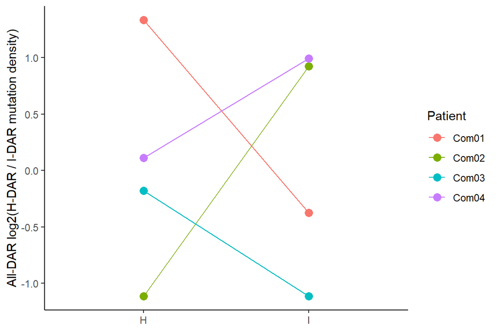

```r
# Connect each patient's H and I scores to show the paired direction.
ggplot(
  dar_summary,
  aes(known_label, lineage_score, group = patient, colour = patient)
) +
  geom_line() +
  geom_point(size = 3) +
  labs(
    x = NULL,
    y = "All-DAR log2(H-DAR / I-DAR mutation density)",
    colour = "Patient"
  ) +
  theme_classic()
```

# Final summary

```r
# Write the paired result as a short text summary.
result <- sprintf(
  "All DARs: expected paired direction %d/%d; sign-test p = %.3g",
  sum(paired$I_minus_H > 0),
  nrow(paired),
  sign_test$p.value
)

writeLines(result, file.path(out_dir, "all_dar_final_result.txt"))
cat(paste(result, collapse = "\n"))
```

```
## All DARs: expected paired direction 2/4; sign-test p = 1
```

Main limitations: only four labelled patient pairs, sparse DAR mutation counts, candidate-like Mutect2 WES calls, no capture/callable-region BED, and mouse-to-human lifted DARs.